# IQ Analysis

## Stat Consulting: Hw 2

Author: Erika Esquinca Class: Bios 6621 Dr. Ryan Peterson Date: 9.15.2020

The purpose of this assignment is to be able to create a new project in R using version control and a git repository. This makes me work reproducible as any changes, previous code, and directories are all linked to github to store on the cloud.

This report is on IQ levels based on lead exposure and must contain the following.

A. A graph showing the IQ levels by location status

B. At least one nicely formatted table using the ‘kable’ function

C. A couple sentences of text (not on the graph, but in the body of the Rmarkdown document) describing the graph and the table

D. Inline calculations giving the values of the means, that will be updated if the data are changed,

E. At least one R code chunk.

First I will begin by exporting the data and taking a look at some values

```r
iq <- read.csv("lead-iq-01.csv")
```

Here we will update the 999 IQ to 99

```r
iq$IQ[10] <- 99
```

Lets begin the analyses by looking at the first 6 rows of our data and the structure

```r
str(iq)
```

```
## 'data.frame':    124 obs. of  2 variables:
##  $ Smelter: Factor w/ 2 levels "Far","Near": 1 1 1 1 1 1 1 1 1 1 ...
##  $ IQ     : num  70 85 86 76 96 94 115 97 128 99 ...
```

```r
head(iq)
```

```
##   Smelter IQ
## 1     Far 70
## 2     Far 85
## 3     Far 86
## 4     Far 76
## 5     Far 96
## 6     Far 94
```

A. A graph showing the IQ levels by location status

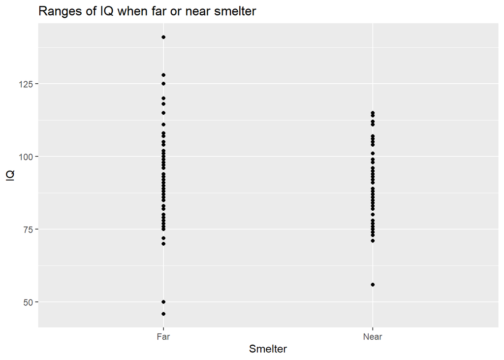

```r
library(ggplot2)
qplot(x= iq$Smelter, y= iq$IQ,
      xlab= "Smelter",
      ylab= "IQ",
      main= "Ranges of IQ when far or near smelter")
```

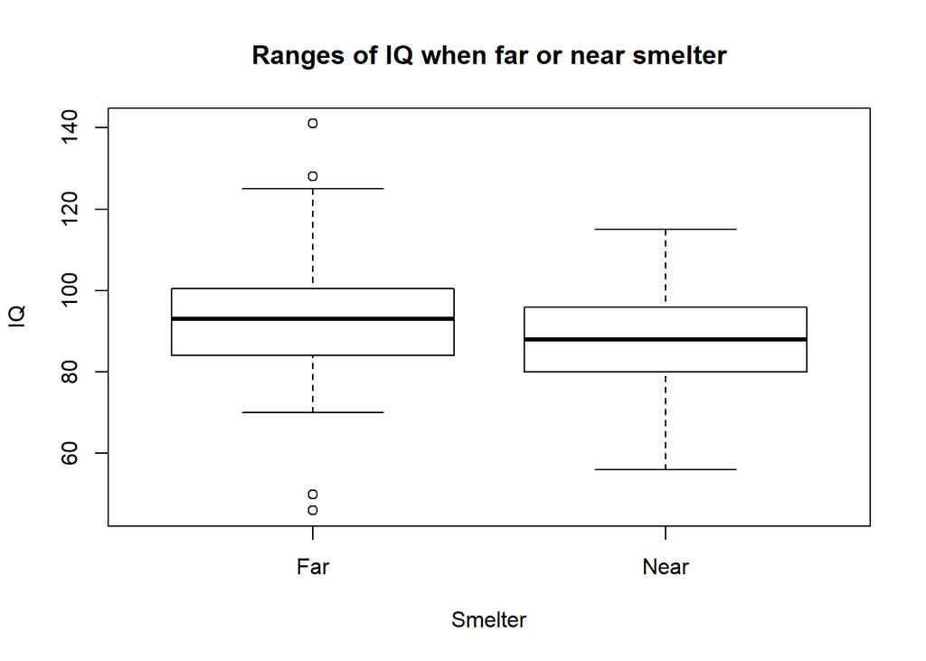

```r
plot(x= iq$Smelter, y= iq$IQ,
      xlab= "Smelter",
      ylab= "IQ",
      main= "Ranges of IQ when far or near smelter")
```

B. At least one nicely formatted table using the ‘kable’ function

```r
library(knitr)
kable(summary(iq))
```

|  | Smelter | IQ |
| --- | --- | --- |
|  | Far :67 | Min. : 46.00 |
|  | Near:57 | 1st Qu.: 81.50 |
|  | NA | Median : 91.00 |
|  | NA | Mean : 91.08 |
|  | NA | 3rd Qu.: 99.00 |
|  | NA | Max. :141.00 |

```r
kable(summary(iq[iq$Smelter == "Far",]))
```

|  | Smelter | IQ |
| --- | --- | --- |
|  | Far :67 | Min. : 46.00 |
|  | Near: 0 | 1st Qu.: 84.00 |
|  | NA | Median : 93.00 |
|  | NA | Mean : 92.69 |
|  | NA | 3rd Qu.:100.50 |
|  | NA | Max. :141.00 |

```r
kable(summary(iq[iq$Smelter == "Near",]))
```

|  | Smelter | IQ |
| --- | --- | --- |
|  | Far : 0 | Min. : 56.00 |
|  | Near:57 | 1st Qu.: 80.00 |
|  | NA | Median : 88.00 |
|  | NA | Mean : 89.19 |
|  | NA | 3rd Qu.: 96.00 |
|  | NA | Max. :115.00 |

D. Inline calculations giving the values of the means, that will be updated if the data are changed,

We can also now input values we can see using inline R code that get updated when the document gets knitted. This way if data changes you don’t have to worry about integrating correct values into the text.

An example of this is the mean of the IQ data we have is 91.0806452

3. Now I will update the data to account for the IQ outlier that was supposed to be 99. I will insert an R script at the top